# `RHugin` Install Instructions for Mac OS X

Last updated by Kjell Konis on 2017-02-02.

### Preliminaries

The `RHugin` package provides an R API for the HUGIN Decision Engine (HDE): both the HDE and R must be installed on the computer in order for the `RHugin` package to function. Since `RHugin` is distributed as a source package, the *command line developer tools* are also required.

#### Install HUGIN and the HUGIN Decision Engine (HDE)

The HUGIN Decision Engine is commercial software available from HUGIN EXPERT.

> http://www.hugin.com

The products *HUGIN Developer* (commercial use) and *HUGIN Researcher* (academic use) include the HUGIN Decision Engine. The HDE is also included with the free demo *HUGIN Lite* (the only permitted use of the free demo is to evaluate HUGIN). HUGIN is distributed on a disk image (i.e., a `.dmg` file). Mount the disk image by double clicking on it, navigate to the mounted disk, and install the HDE by dragging the HDE folder and dropping it onto the *Applications* alias. You may also want to install the other components (HUGIN GUI, documentation, etc.) but these are not required for `RHugin`.

#### Install R

Just in case you don’t already have R installed… R is available from the CRAN repository.

> https://cloud.r-project.org/

The installer for the most recent version of R can be found by following the *Download R for (Mac) OS X* link.

#### Install *Command Line Developer Tools*

Start R and run the following command to install the *command line developer tools*.

```r
system2("xcode-select", "--install")
```

A dialog box will pop up and prompt you to install the command line developer tools. Click *Install* (note: this command must be run by a user with administrative privileges).

If you get the following error

```
xcode-select: error: command line tools are already installed, use "Software Update" to install updates
```

the command line developer tools are already installed and you could have skipped this section.

### RHugin Package Depedencies

The RHugin package has dependencies on the `graph` and `Rgraphviz` packages. These packages are part of Bioconductor and can be installed by running the following two R commands.

```r
source("https://bioconductor.org/biocLite.R")
biocLite(c("graph", "Rgraphviz"))
```

### Install the RHugin Package

First, set the `HUGINHOME` environment variable so that `RHugin` can find the HUGIN Decision Engine (HDE). The value (i.e., the `"/Applications/HDE8.4-x64"` in the code below) should be the full path to the HDE folder that you installed in the *Preliminaries* section.

```r
Sys.setenv(HUGINHOME = "/Applications/HDE8.4-x64")
```

Then, install the `RHugin` package from `RHugin`’s R-Forge repository with the following R command.

```r
install.packages("RHugin", repos = "http://rhugin.r-forge.r-project.org",
                 type = "source", INSTALL_opts="--no-multiarch")
```

### Quick Test

To check that everything went as planned run the following code to plot one of the example networks provided by HUGIN.

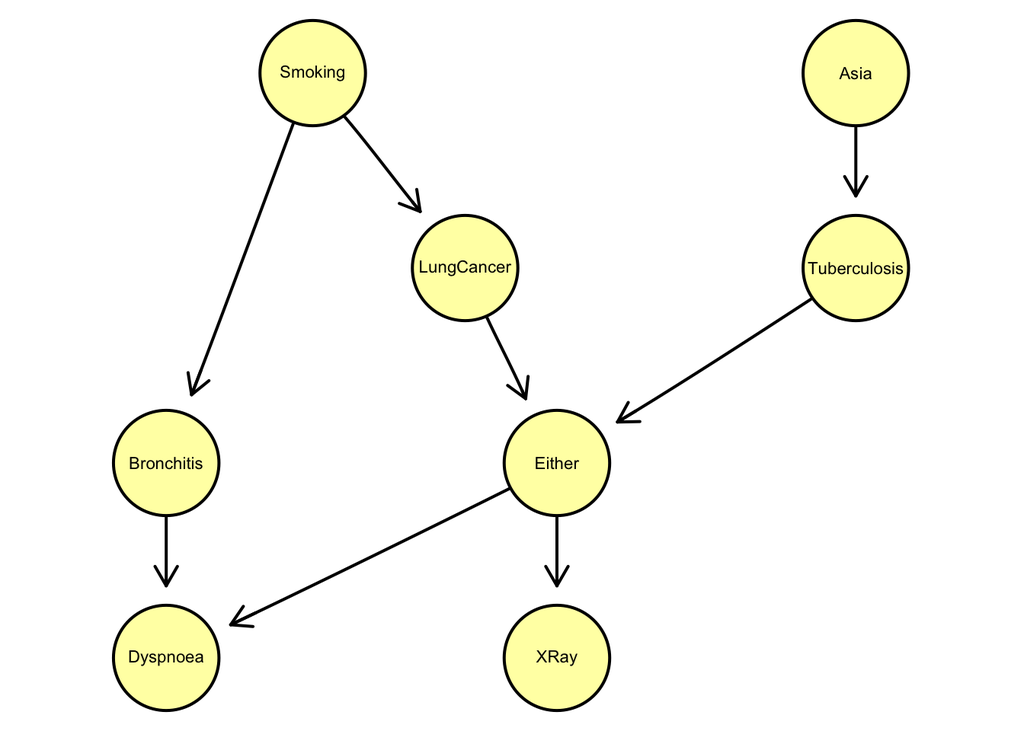

```r
library(RHugin)
demo("asia", echo = FALSE)
plot(asia)
```

Happy HUGINing with `RHugin`!

Copyright 2017 Kjell Konis